# GBI6 - BIOINFORMÁTICA

EXAMEN FINAL

Cunguan Jomely

marzo 29, 2022

**Bienvenidos al examen final de GBI6 - Bioinformática.**

Esta permitido consultar todo material disponible: diapositivas, google…Sin embargo **NO** esta permitido consultar a sus colegas.

Los contenidos de esta evaluación corresponden a los temas:

- Tipos de datos
- Estructuras de control
- Funciones
- Manipulación de datos
- Estadística básica
- Visualización de datos

Ustedes estan utilizando el R Markdown. Las instruciones son:

- Creen una carpeta en su computador donde guarden este cuaderno .Rmd y la data que van a utilizar.
- Definan a esa carpeta como su directorio de trabajo.
- Arriba, donde dice “author”, deben llenar sus nombres.
- Los codigos deben ser escritos dentro de las cajas que inician y terminan con ``` o dentro de las cajas indicadas abajo de las preguntas.
- Al final del examen deben utilizar el comando “Knit” para generar un archivo .html
- Es recomendable crear una copia de este script guía.
- Cargue el archivo .html en el aula virtual, donde dice “ExamenFinal”.
- Asegúrese de responder explícitamente cada una de las preguntas. Suerte!

## **1.1 [7 PUNTOS]**

Lea el artículo [Reitmayer, C.M. et al. 2021](https://doi.org/10.1038/s42003-021-02236-5). El estudio trata sobre el tipo de convergencia de las frecuencias de aleteo de mosquitos machos y hembras de los mosquitos vectores del Dengue. Asimismo, esta convergencia quieren anañizar si está asociado al procentaje de melanización (No, partial, full) y los efectos de estas características en la sobreviviencia de la progenie resultante.

La información asociada al estudio ha sido descargada y se encuentra en la carpeta **data** (si desea revisar los detalles de la data ingrese a [datadryad.org](https://datadryad.org/stash/dataset/doi:10.5061/dryad.ffbg79ct0)), asimismo lea el archimo ```Readme.docx````.

En esta evaluación. su trabajo consiste es generar figura 1 (1a, 1b, 1c) tal como se muestra en el artículo.

Realice el análisis paso a paso, comentando lo que hacen las líneas de cósigo.

### Librerías

```r
# cargue aquì las librerias, de ser necesario instale las que requiera

library(readr)
library(tidyr)
library(dplyr)
```

```r
library(ggplot2)
library(ggpubr)
```

### Exploración

```r
getwd() ## observamos en el directorio donde nos encontramos.
```

```
## [1] "C:/Users/usuario/Desktop/proyectos_2022/bioinformatica/recuperacion/resolucion"
```

```r
## ubicamos en el directorio que creamos la carpeta donde estara la data y el archivo .rmd

setwd("C:/Users/usuario/Desktop/proyectos_2022/bioinformatica/recuperacion/resolucion/")

## cargamos la data melanization.csv

melanization <- read_csv("melanization.csv")
## creamos tres df que filtran los datos de interes segun el gráfico

## En el primero seleccionamos y filtramos con los criterios parental.pair, melanization y sex
## posteriormente agregamos un pipe y utilizamos la función summarise para contar la frecuencia que se repite
## cada uno de los criterios ej: parental pair = 1, melanization = 1, sex = male

datos_1 <- melanization %>% group_by(parental.pair, melanization, sex) %>%
  summarise(count = n()) %>%
  filter(parental.pair >=1, melanization >=0, sex == "male" | sex == "female")
## el el segundo df mediante la funcion filter se elegio el sexo male

datos_2 <- melanization %>% group_by(parental.pair, convergence, melanization, sex) %>%
  summarise(count = n()) %>%
  filter(parental.pair >=1, convergence == "converged" | convergence == "nonconverged",
         sex == "male")
```

```
## 'melanization'. You can override using the `.groups` argument.
```

```r
## el el tercer df mediante la funcion filter se elegio el sexo female

datos_3 <- melanization %>% group_by(parental.pair, convergence, melanization, sex) %>%
  summarise(count = n()) %>%
  filter(parental.pair >=1, convergence == "converged" | convergence == "nonconverged",
         sex == "female")
```

```
## 'melanization'. You can override using the `.groups` argument.
```

```r
## Modifico la variable melanization de 0, 1 y 2 a Not, Partial y Full en los tres df

datos_1$melanization[datos_1$melanization == 0] <- "Not"
datos_1$melanization[datos_1$melanization == 1] <- "Partial"
datos_1$melanization[datos_1$melanization == 2] <- "Full"

datos_2$melanization[datos_2$melanization == 0] <- "Not"
datos_2$melanization[datos_2$melanization == 1] <- "Partial"
datos_2$melanization[datos_2$melanization == 2] <- "Full"

datos_3$melanization[datos_3$melanization == 0] <- "Not"
datos_3$melanization[datos_3$melanization == 1] <- "Partial"
datos_3$melanization[datos_3$melanization == 2] <- "Full"

## se creo tres vectores vacios, uno para cada df

suma_1 <-vector()
suma_2 <-vector()
suma_3 <-vector()

## Creación de tres vectores que contiene el total de numero de individuos por cada parental.pair 44

## Se lo realizo los tres df

for (i in 1:44) {
  suma_1[length(suma_1) + 1] <- datos_1 %>% filter(parental.pair == i) %>%
    pull(count) %>% sum
}

for (i in 1:44) {
  suma_2[length(suma_2) + 1] <- datos_2 %>% filter(parental.pair == i) %>%
    pull(count) %>% sum
}

for (i in 1:44) {
  suma_3[length(suma_3) + 1] <- datos_3 %>% filter(parental.pair == i) %>%
    pull(count) %>% sum
}

## se creo tres df vacios

porciento_1 <- NULL

porciento_2 <- NULL

porciento_3 <- NULL

## se creo una nueva variable mediante la función mutate, esta variable es el porcentaje de frecuencia
## en cada uno de los parental.pair.

for (i in 1:44) {
  prueba_1 <- datos_1 %>%  filter(parental.pair == i) %>%
  mutate(porcentaje = count*100/suma_1[i]) ## crea una nueva columna y realiza operaciones entre ellas.
  porciento_1 <- rbind(porciento_1, prueba_1) ## sirve para unir filas
}

for (i in 1:44) {
  prueba_2 <- datos_2 %>%  filter(parental.pair == i) %>%
    mutate(porcentaje = count*100/suma_2[i])
  porciento_2 <- rbind(porciento_2, prueba_2)
}

for (i in 1:44) {
  prueba_3 <- datos_3 %>%  filter(parental.pair == i) %>%
    mutate(porcentaje = count*100/suma_3[i])
  porciento_3 <- rbind(porciento_3, prueba_3)
}

## posteriormente se ordeno los datos mediante la función factor para que las etiquetas sex aparezca
## primero la del hombre

porciento_1$sex = factor(porciento_1$sex, levels = c("male", "female"))

## posteriormente se ordeno los datos mediante la función factor para que las etiquetas melanization
## aparezca  en el orden segun la figura del articulo


porciento_1$melanization = factor(porciento_1$melanization, levels = c("Not", "Partial", "Full"))

## se creo un plot y se guardo en una variable

## funcion aes sirve para agregar los datos de "x" y de "y", col = para separar mediante el sex
plot_1 <- ggplot(porciento_1, aes(x = melanization, y = porcentaje, col = sex )) +
  ## etiqueta labs sirve para agregar los titulos en el eje x y y
  labs(x = "Degree of melanization", y = "Proportion of beads" ) +
  ## theme_classic mantiene el fondo blanco,
  ## lwd y fatter grosor de las lineas del boxplot y mediana respectivamente
  theme_classic() + geom_boxplot(lwd = 1, fatten = 1) +
  ## strip.background y strip.txt.x elimina las leyenda
  theme(strip.background = element_blank(),
        strip.text.x = element_blank(),
        axis.title.x = element_text(face = "bold", size = 14), ## tamaño y negrita de la etiqueta del eje x
        axis.title.y = element_text(face = "bold", size = 14)) + ## tamaño y negrita de la etiqueta del eje y
  ## reagrupar los boxplots mediante el sexo y la funcion scale añadir los colores manualmente
  facet_wrap(~sex) + scale_color_manual(values = c("darkgray", "red"))

color = c("darkgray", "red")

## ajustamos el orden de la presentacion del eje x mediante la funcion factor

porciento_2$melanization = factor(porciento_2$melanization,
                                  levels = c("Not", "Partial", "Full"))

plot_2 <- ggplot(porciento_2, aes(x = convergence, y = porcentaje, col = melanization)) +
  labs(x = "Harmonic convergence status", y = "Proportion of beads" ) +
  theme_classic() +
  geom_boxplot(aes(linetype = melanization), lwd = 1, fatten = 1, color = "darkgray") +
  theme(axis.title.x = element_text(face = "bold", size = 14),
        axis.title.y = element_text(face = "bold", size = 14)) +
  ## scale_linetype permite reprentar las lineas del boxplot de diferente forma. Por ejemplo, lineas
  ## contiunas o discontinuas
  scale_linetype_manual(values=c("twodash", "longdash", "solid"))

## ajustamos el orden de la presentacion del eje x mediante la funcion factor

porciento_3$melanization = factor(porciento_3$melanization,
                                  levels = c("Not", "Partial", "Full"))

plot_3 <- ggplot(porciento_3, aes(x = convergence, y = porcentaje, col = melanization)) +
  labs(x = "Harmonic convergence status", y = "Proportion of beads" ) +
  theme_classic() +
  geom_boxplot(aes(linetype = melanization), lwd = 1, fatten = 1, color = "red") +
  theme(axis.title.x = element_text(face = "bold", size = 14),
        axis.title.y = element_text(face = "bold", size = 14)) +
  scale_linetype_manual(values=c("twodash", "longdash", "solid"))

## contar el porcentaje se realizo la siguiente linea como ejemplo
## porciento_3 %>% filter(melanization == "Full" & sex == "female" & convergence == "nonconverged") %>% pull(count) %>% sum

## resultados
## Male, converged, n= 173, 51% Not; 30% Partial; 19% Fully
## Male, not converged, n = 130, 40% Not; 29% Partial; 31% Fully


## Female, converged, n = 280, 21% Not; 39% Partial; 40% Fully
## Female, not converged, n = 221,  19% Not; 38% Partial ; 43% Fully
```

### Gráfica 1a

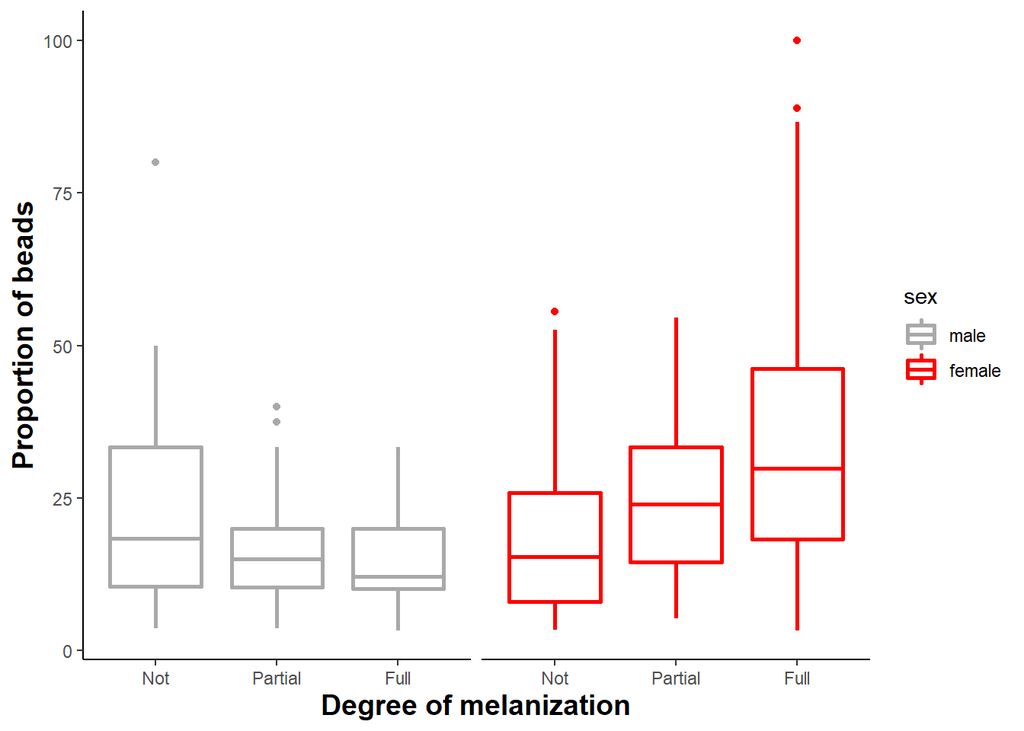

```r
plot_1
```

### Gráfica 1b

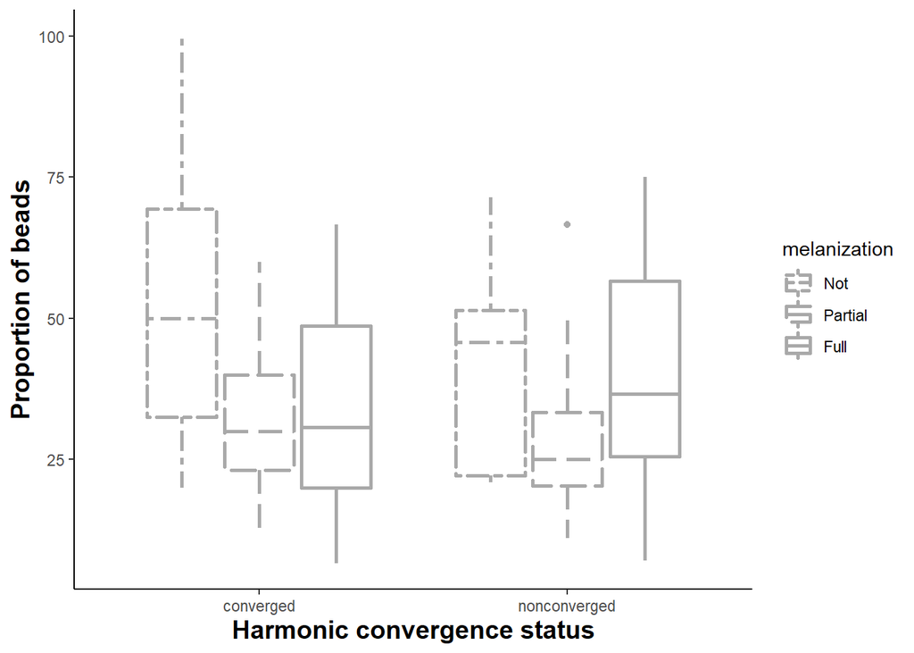

```r
plot_2
```

### Gráfica 1c

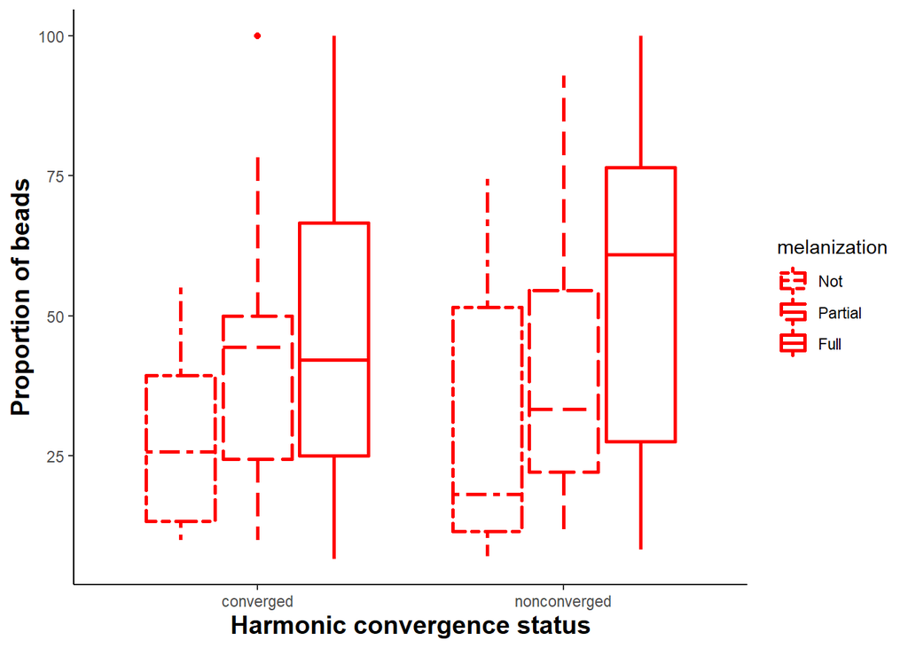

```r
plot_3
```

### Gráfica 1

(los tres juntos, como se muestra en el artículo)

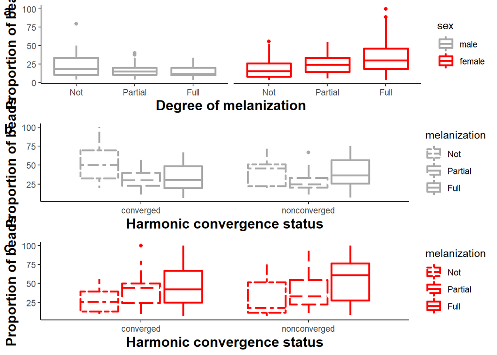

```r
ggarrange(plot_1, plot_2, plot_3, ncol = 1, nrow = 3, labels = c("a", "b", "c"),
          common.legend = FALSE)
```

### Análisis del resultado en sus propias palabras.

Guarde la figura 1 como un archivo .jpg, con una reoslución de 300 dpi.

```r
# escriba el código para guardar la figura 1
ggsave(filename = "Figura_1.jpg", width = 7 , height = 9, device='jpg',
       dpi=300)
```

## **1.2 [3 PUNTOS]**

Utilice git para guardar la figura y su cuaderno .Rmd en GitHub.

Inserte aquí la captura de pantalla de las instrucciones realizadas en el terminal (Git Bash)

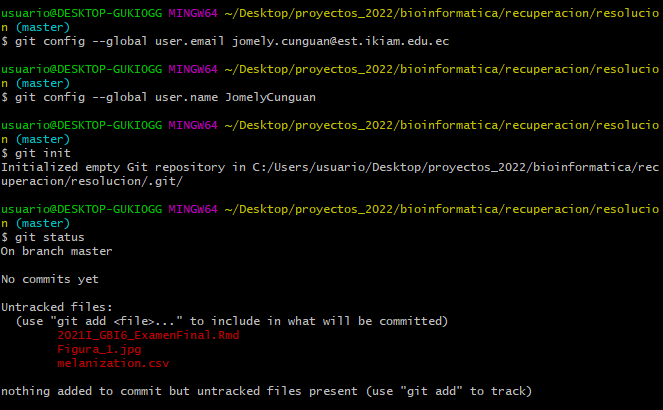

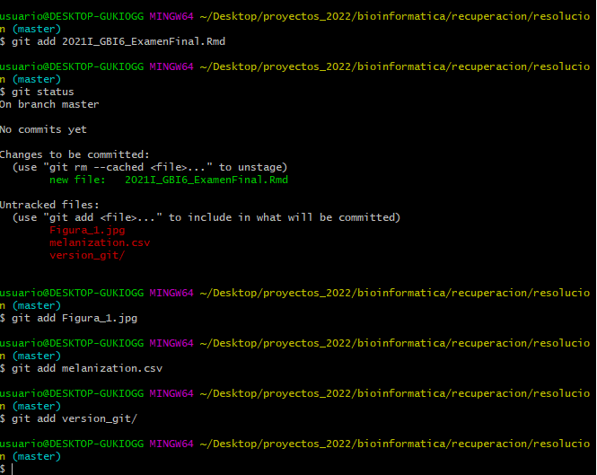

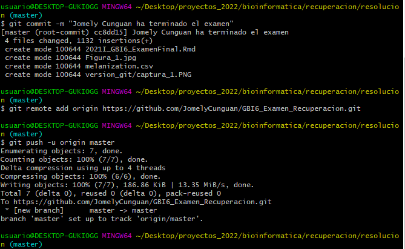

Inserte aquí el enlace donde se encuentra la figura y el cuaderno .Rmd en GitHub.

https://github.com/JomelyCunguan/GBI6_Examen_Recuperacion